# Practical Machine Learning Course Project

## Re-training the best performed model by using full-size training set

So far, only a portion of training set is trained by decision tree and random forest algorithms. Before the finally picked model is used for testing dataset, it must be retrained by using complete training set for hest accuracy in prediction. In the following, above process is repeated by using full training set : dsTrain

Removal of variables near zero values from data

```r
nzv<- nearZeroVar(dsTrain, saveMetrics=TRUE)

dsTrain <- dsTrain[,nzv$nzv==FALSE]
```

Removal of first column for possible interferrence of ID to the prediction

```r
dsTrain <- dsTrain[c(-1)]
```

Clean variables with equal to or more than 70% NA

```r
trainingNA70 <- dsTrain
for(i in 1:length(dsTrain)) {
  if( sum( is.na( dsTrain[, i] ) ) /nrow(dsTrain) >= .7) {
    for(j in 1:length(trainingNA70)) {
      if( length( grep(names(dsTrain[i]), names(trainingNA70)[j]) ) == 1)  {
        trainingNA70 <- trainingNA70[ , -j]
      }
    }
  }
}

#  set columns to original variable name
dsTrain <- trainingNA70
rm(trainingNA70)
dim(dsTrain)
```

```
## [1] 19622    58
```

## Prediction with an algorithem: Random Forests again on full training set

```r
modFitRFBfull <- randomForest(classe ~. , data=dsTrain)
```

Create a plot

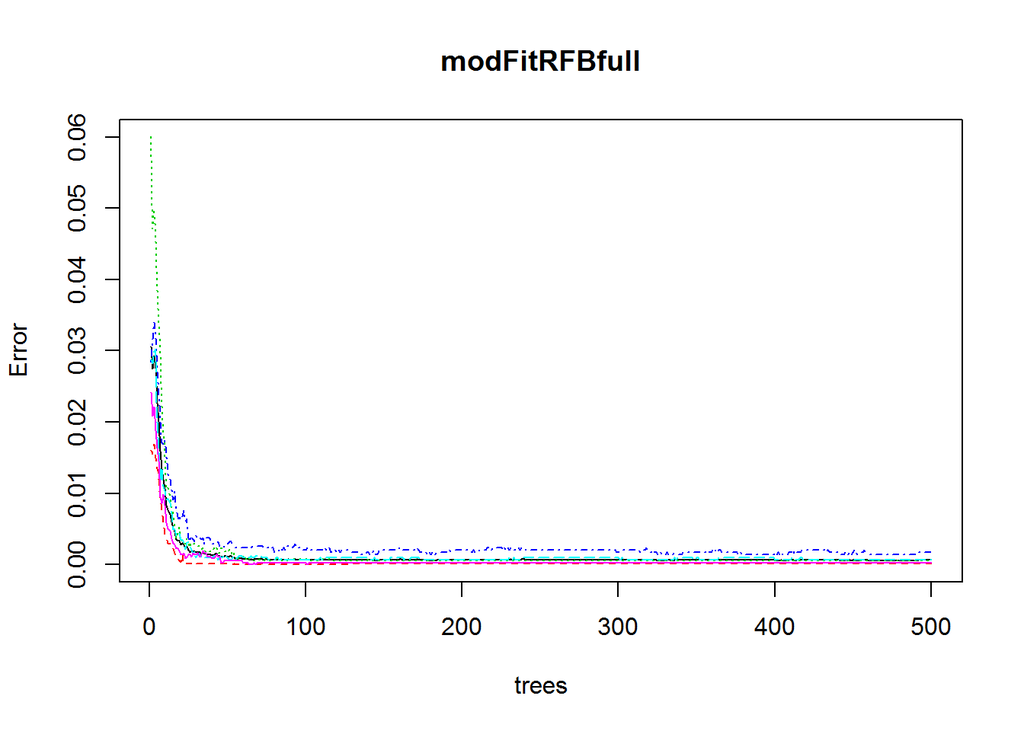

```r
  plot(modFitRFBfull)
```

Retrain the model

```r
  predictionsRFfull <- predict(modFitRFBfull, myTesting, type = "class")
```

Estimate the result by using confusionMatrix

```r
  confusionMatrix(predictionsRFfull, myTesting$classe)
```

```
## Confusion Matrix and Statistics
##
##           Reference
## Prediction    A    B    C    D    E
##          A 1395    0    0    0    0
##          B    0  949    0    0    0
##          C    0    0  855    0    0
##          D    0    0    0  804    0
##          E    0    0    0    0  901
##
## Overall Statistics
##
##                Accuracy : 1
##                  95% CI : (0.9992, 1)
##     No Information Rate : 0.2845
##     P-Value [Acc > NIR] : < 2.2e-16
##
##                   Kappa : 1
##  Mcnemar's Test P-Value : NA
##
## Statistics by Class:
##
##                      Class: A Class: B Class: C Class: D Class: E
## Sensitivity            1.0000   1.0000   1.0000   1.0000   1.0000
## Specificity            1.0000   1.0000   1.0000   1.0000   1.0000
## Pos Pred Value         1.0000   1.0000   1.0000   1.0000   1.0000
## Neg Pred Value         1.0000   1.0000   1.0000   1.0000   1.0000
## Prevalence             0.2845   0.1935   0.1743   0.1639   0.1837
## Detection Rate         0.2845   0.1935   0.1743   0.1639   0.1837
## Detection Prevalence   0.2845   0.1935   0.1743   0.1639   0.1837
## Balanced Accuracy      1.0000   1.0000   1.0000   1.0000   1.0000
```

## Prediction with Random forest on test data

```r
  predictionsRFdsTest <- predict(modFitRFBfull, dsTest, type = "class")
  predictionsRFdsTest
```

[output not shown]

```r
  # Write the results to a text file for submission
  pml_write_files = function(x){
    n = length(x)
    for(i in 1:n){
      filename = paste0("problem_id_",i,".txt")
      write.table(x[i],file=filename,quote=FALSE,row.names=FALSE,col.names=FALSE)
    }
  }

   #pml_write_files(predictionsRFdsTest)
```

## Reference

Ugulino, W.; Cardador, D.; Vega, K.; Velloso, E.; Milidiu, R.; Fuks, H. Wearable Computing: Accelerometers’ Data Classification of Body Postures and Movements. Proceedings of 21st Brazilian Symposium on Artificial Intelligence. Advances in Artificial Intelligence - SBIA 2012. In: Lecture Notes in Computer Science. , pp. 52-61. Curitiba, PR: Springer Berlin / Heidelberg, 2012. ISBN 978-3-642-34458-9. DOI: 10.1007/978-3-642-34459-6_6.

Read more: http://groupware.les.inf.puc-rio.br/har#sbia_paper_section#ixzz4BHMliVa5